# Analysis Of Data From Activity Monitoring Device

# Date: February 10, 2018

# Synopsis:

With the advancement of technology ,it is now possible to collect a large amount of data about personal movement using activity monitoring devices such as a Fitbit, Nike Fuelband, or Jawbone Up. These type of devices are part of the “quantified self” movement – a group of enthusiasts who take measurements about themselves regularly to improve their health, to find patterns in their behavior, or because they are tech geeks. But these data remain under-utilized both because the raw data are hard to obtain and there is a lack of statistical methods and software for processing and interpreting the data.

Here we have used an activity data set to analyse and understand the pattern of steps of an individual taken at 5 minute intervals.

```r
library(knitr)
library(dplyr)
```

```r
opts_chunk$set(echo = TRUE)
library(ggplot2)
```

# Loading the Dataset into R

1.1 Reading the dataset into R

1.2 converting the dates into date class variable

```r
activitydata <- read.csv2("activity.csv",sep = ",",header = TRUE)
activitydata$date = as.Date(activitydata$date, "%Y-%m-%d")
```

# An overview of the Dataset being used

```r
head(activitydata)
```

```
##   steps       date interval
## 1    NA 2012-10-01        0
## 2    NA 2012-10-01        5
## 3    NA 2012-10-01       10
## 4    NA 2012-10-01       15
## 5    NA 2012-10-01       20
## 6    NA 2012-10-01       25
```

# Histogram of the total number of steps taken each day

2.1 Copying the original data to another data frame for analysis.

2.2 Converting the dates into factors

2.3 Summarising the daily steps grouped by the dates.

```r
testdata <- activitydata
testdata$date <- as.factor(testdata$date)
grouped_dates <- testdata %>% group_by(date) %>% summarise(steps=sum(steps))
grouped_dates$date <-as.Date(grouped_dates$date,"%Y-%m-%d")
head(grouped_dates)
```

```
## # A tibble: 6 x 2
##         date steps
##       <date> <int>
## 1 2012-10-01    NA
## 2 2012-10-02   126
## 3 2012-10-03 11352
## 4 2012-10-04 12116
## 5 2012-10-05 13294
## 6 2012-10-06 15420
```

2.4 Plotting the histogram for total number of steps taken each day.

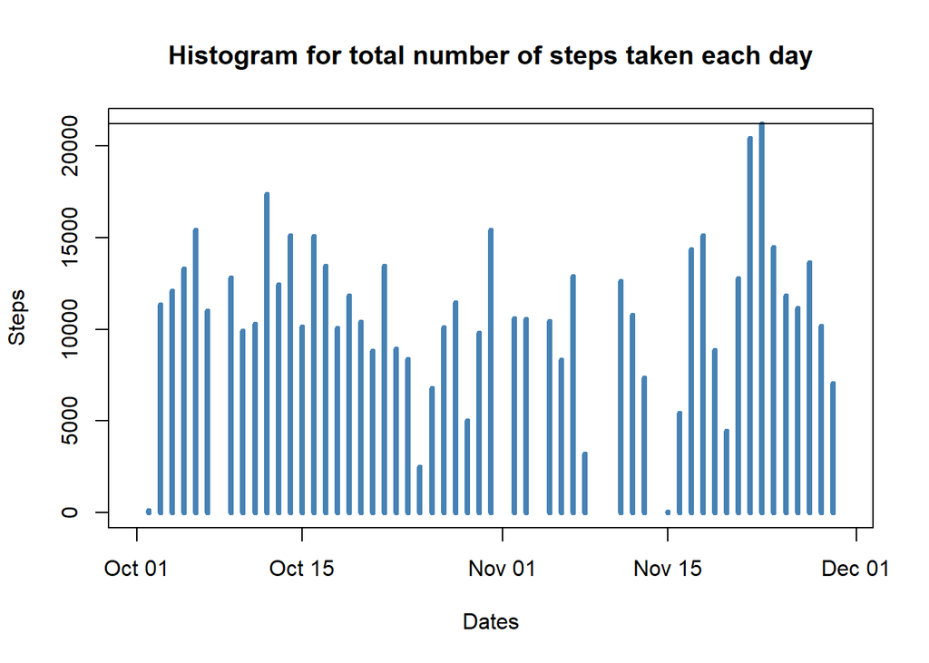

```r
plot(grouped_dates$steps~grouped_dates$date,type = "h", lwd = 4 , col = "steel blue", xlab = "Dates" , ylab = "Steps" ,main = "Histogram for total number of steps taken each day")
abline(h = max(grouped_dates$steps,na.rm = TRUE))
```

# Mean and median number of steps taken each day

3.1 Mean steps taken

3.2 Median of the steps taken

```r
mean_steps <- mean(grouped_dates$steps, na.rm = TRUE)
mean_steps
```

```
## [1] 10766.19
```

```r
median_steps <- median(grouped_dates$steps,na.rm = TRUE)
median_steps
```

```
## [1] 10765
```

# Time series plot of the average number of steps taken

4.1 Getting the average of the steps on each interval

```r
average_steps <- testdata %>% filter(!is.na(steps)) %>% group_by(interval) %>% summarise(steps = mean(steps))
```

4.2 Time series plot of the data

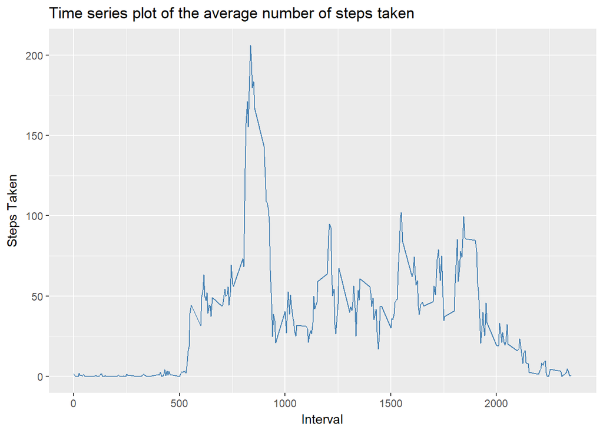

```r
ggplot(average_steps,aes(x = interval, y = steps)) + geom_line(color ="steel blue") + labs(title = "Time series plot of the average number of steps taken" , x= " Interval " , y = " Steps Taken ")
```

# The 5-minute interval that, on average, contains the maximum number of steps

```r
average_steps[(which.max(average_steps$steps)),]
```

```
## # A tibble: 1 x 2
##   interval    steps
##      <int>    <dbl>
## 1      835 206.1698
```

# Code to describe and show a strategy for imputing missing data

6.1 Checking for the steps with Na values

6.2 Calculating the average of steps at 5 minute time intervals

6.3 Replacing the Na values with the corresponding average steps taken.

```r
step_na <- is.na(testdata$steps)
average_steps <- tapply(testdata$steps,testdata$interval,mean,na.rm = TRUE,simplify = TRUE)
testdata$steps[step_na] <-average_steps[as.character(testdata$interval[step_na])]
head(testdata)
```

```
##       steps       date interval
## 1 1.7169811 2012-10-01        0
## 2 0.3396226 2012-10-01        5
## 3 0.1320755 2012-10-01       10
## 4 0.1509434 2012-10-01       15
## 5 0.0754717 2012-10-01       20
## 6 2.0943396 2012-10-01       25
```